# TTP Predictive Marker Analysis: Statistical Analysis

Chong Kim

04 March, 2018

*Please read the README.md file for more information.*

# 1 Objective

This project is based on a database that was constructed with 73 patients that have Acquired [Thrombotic Thrombocytopenic Purpura (TTP)](https://en.wikipedia.org/wiki/Thrombotic_thrombocytopenic_purpura) at the Unviersity of Alabama Birmingham Hospital. The goal of this project is to determine the predictive markers for outcomes related to TTP patients antigen levels.

The previous exploratory analysis indicated some significant univariate association between predictors and mortality (Other outcomes such as exacerbation and relapse didn’t show any strong association with predictors in the data).

In this report, we will go through traditional statistical model (e.g. logistic regression) and ML methods (e.g. decision tree, random forest, and support vector) to determine which factors are highly associated wtih outcomes in TTP patients.

# 2 Logistic Regression Model

## 2.1 Logistic Regression without Variable Selection

- This is just an illustration to indicate that:
  - You should never include all variables just for the sake of it.
  - There are collinearities that are present thus the standard errors will be highly inflated.
  - Note: Since there were missing values in some of the variables that seemed to be significant, we imputed the values using median imputation. We also excluded some variables that had near zero variance.

### 2.1.1 Table 1: logistic regression with all variabiles (based on univariate p-value)

|  | *Dependent variable:* |
| --- | --- |
|  | Mortality |
| age | -0.182 |
|  | (7,740.234) |
| sexMale | 7.855 |
|  | (218,170.400) |
| raceAfro-Hispanic | 25.060 |
|  | (1,088,720.000) |
| raceW | 20.464 |
|  | (448,290.100) |
| btypeAB | 3.199 |
|  | (625,585.000) |
| btypeB | 2.849 |
|  | (251,033.800) |
| btypeO | 20.630 |
|  | (195,498.600) |
| cmb_cnsYes | -7.638 |
|  | (252,163.000) |
| cmb_abdYes | 0.930 |
|  | (250,209.000) |
| cmb_chstYes | -28.934 |
|  | (425,884.400) |
| htnYes | 6.159 |
|  | (293,084.800) |
| dmYes | 21.134 |
|  | (477,737.800) |
| pregYes | -3.523 |
|  | (634,413.800) |
| time_plt_stbl | -5.326 |
|  | (71,524.110) |
| plt_stb_7 | -40.842 |

[output cut: 67 more lines]

- As you can see, there is just too many variables in the output and the model specification is (likely) wrong.
- The log-likelihood and the AIC isn’t an appropriate value.

- Since we won’t be using all the variables, we will be selecting the necessary variables using L1 and L2 (shrinkage) regularization method. The basic idea is to shrink the $\beta$ coefficients of the regresion models so as to prevent overfitting (more information [here](https://en.wikipedia.org/wiki/Regularization_%28mathematics%29)).
- Below we will also conduct a 5x-repeated 10-fold Cross Validation (5x-10CV) to determine the appropriate shrinkage parameter (i.e. hyperparameter) value. This will allow us to narrow down on the important variables.

### 2.2.1 Figure 1: Shrinkage Method

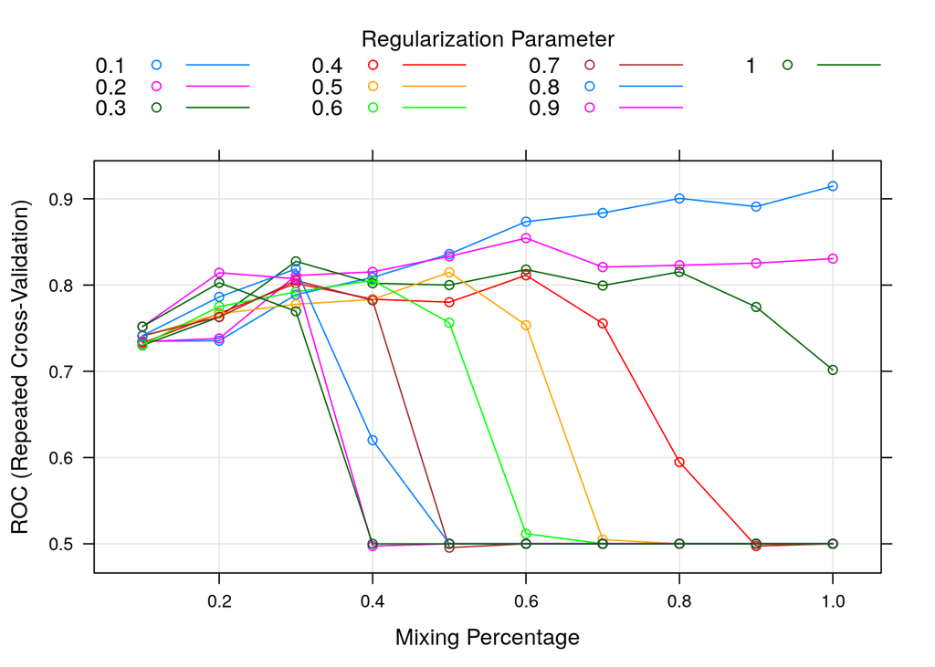

- Figure 1 indicates the cross-validated performance of the GLM prediction model based on various hyperparameter values.
  - The performance criteria we are looking at is the Receiver Operating Characteristic (ROC) curve and ideally we would like the ROC value to be close to 1.0.
  - Based on the figure, we can see that higher values of the mixing parameter and lower value of the regularization parameter achieves a higher ROC value.

### 2.2.2 Figure 2: GLM-based Important Variables

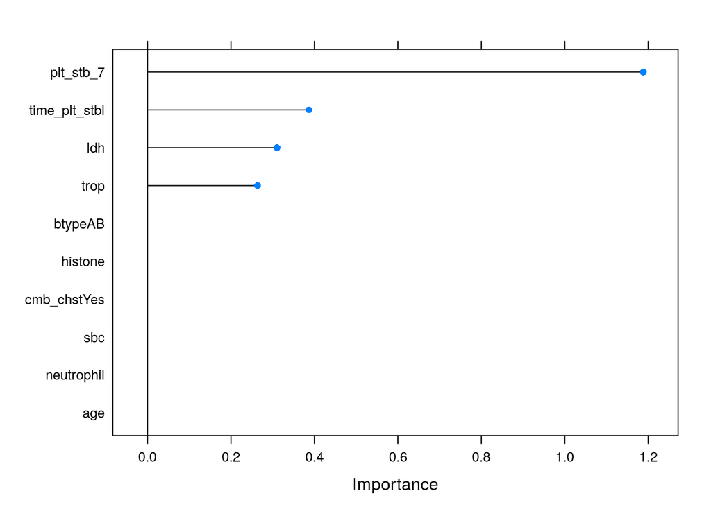

- Figure 2 indicates the most important variables (based on the shrinkage method).
  - The most important variable is plt_stb_7
  - The 2nd important variable is time_plt_stbl
  - The 3rd important variable is ldh
  - Since we are interested in biomarkers, if we exclude the first two variables and run the analysis again let’s see if twe get any interesting predictive markers.

### 2.2.3 Figure 3: Shrinkage Method w/o Platelet Stabilization Time Variables

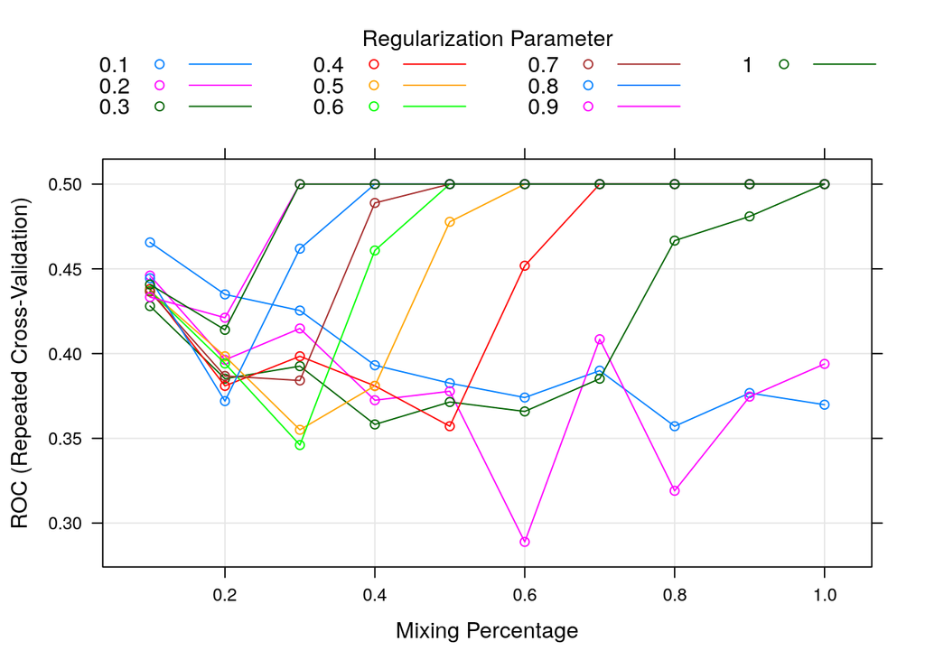

- Figure 3 indicates the cross-validated performance of the GLM prediction model when excluding the time to platelet stabilization variables.
  - Unfortunately the ROC decreases drastically when we exlude the above variables in the model.

### 2.2.4 Figure 4: GLM-based Important Variables w/o Platelet Stabilization Variables

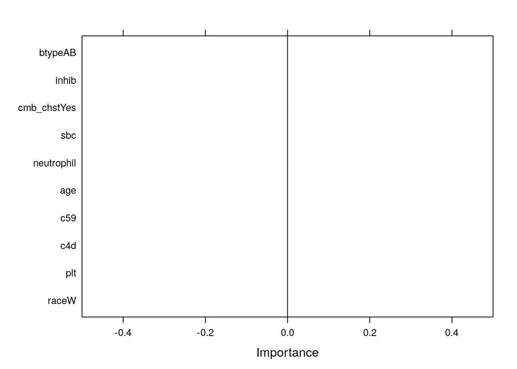

# 3 Decision Tree Model

- Using a [decision tree algorithm](https://en.wikipedia.org/wiki/Decision_tree_learning), we used a similar approach to hyperparameter selection using 5x10CV.

## 3.1 Decision Tree with 5x 10-CV

- Here, we are going to tune the complexity parameter and minsplit

### 3.1.1 Figure 5: Decision Tree Hyper Parameter Tuning

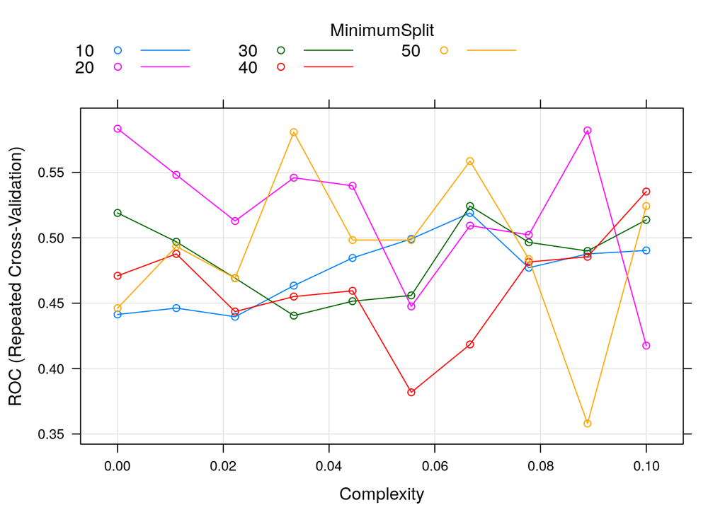

### 3.1.2 Figure 6: Decision Tree Important Variables

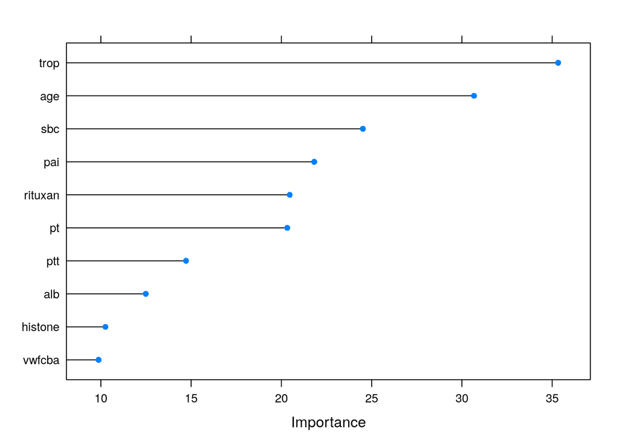

# 4 Random Forest Model

- Using a [Random Forest algorithm](https://en.wikipedia.org/wiki/Random_forest), we used a similar approach to hyperparameter selection using 5x10CV.

## 4.1 Random Forest with 5x 10-CV

- Here, we are going to tune the number of variables randomly sampled (`mtry`) and number of trees to grow (`ntree`)

### 4.1.1 Figure 7: Random Forest Hyperparameter Tuning

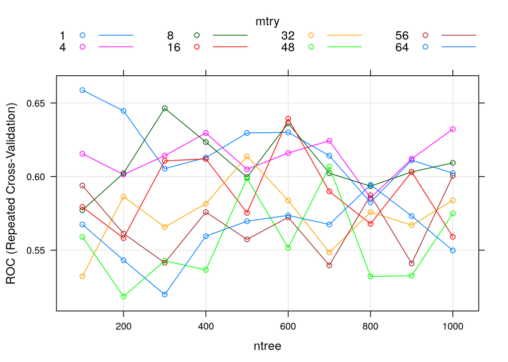

### 4.1.2 Figure 8: Random Forest Variable Importance

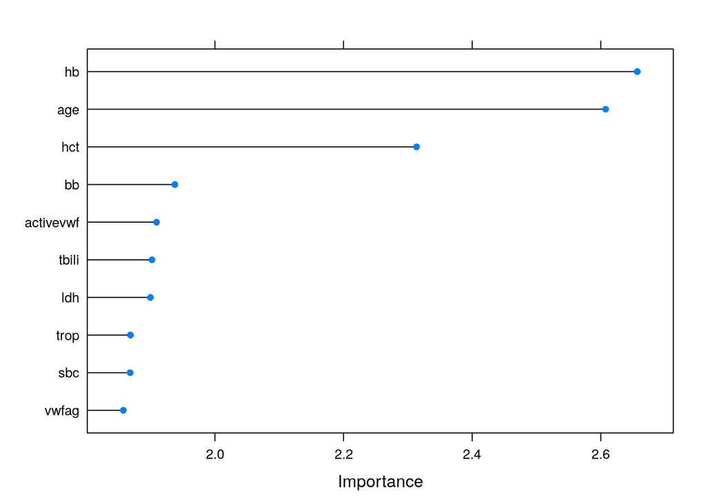

# 5 Support Vector Model

- Using a [Support Vector Machine algorithm](https://en.wikipedia.org/wiki/Support_vector_machine), we used a similar approach to hyperparameter selection using 5x10CV.

## 5.1 Support Vector Machine with 5x 10-CV

- Here, we are going to tune the $\sigma$ (`sigma`) and cost parameter (`C`)
- First we will use a linear kernel (i.e. hyper parameter space division is linear)

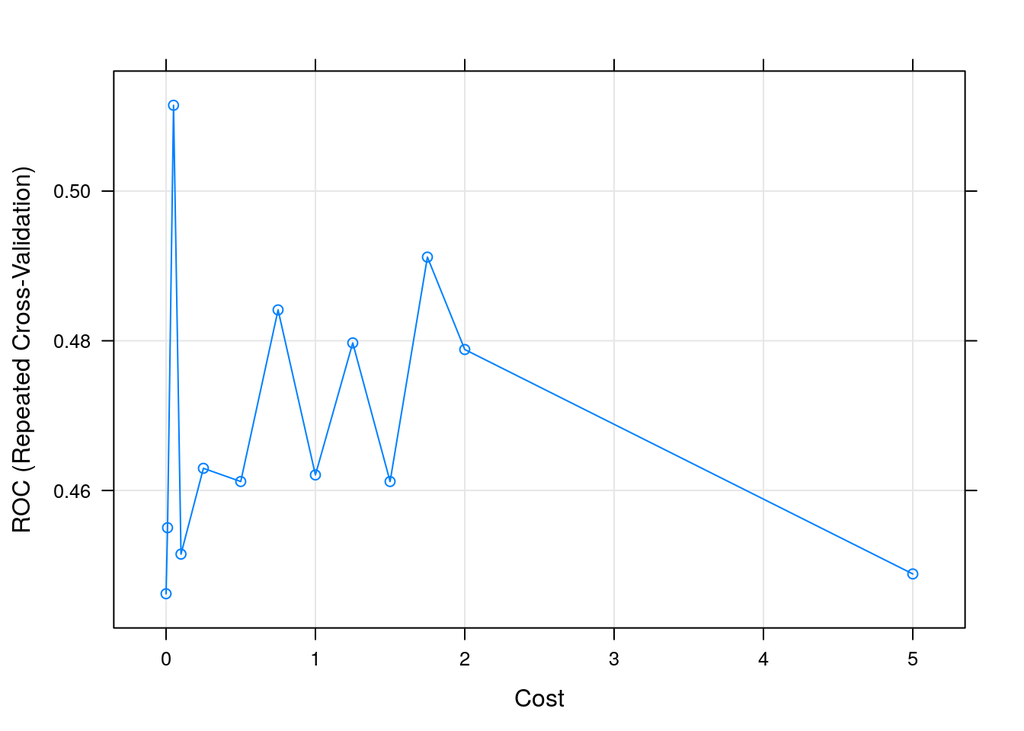

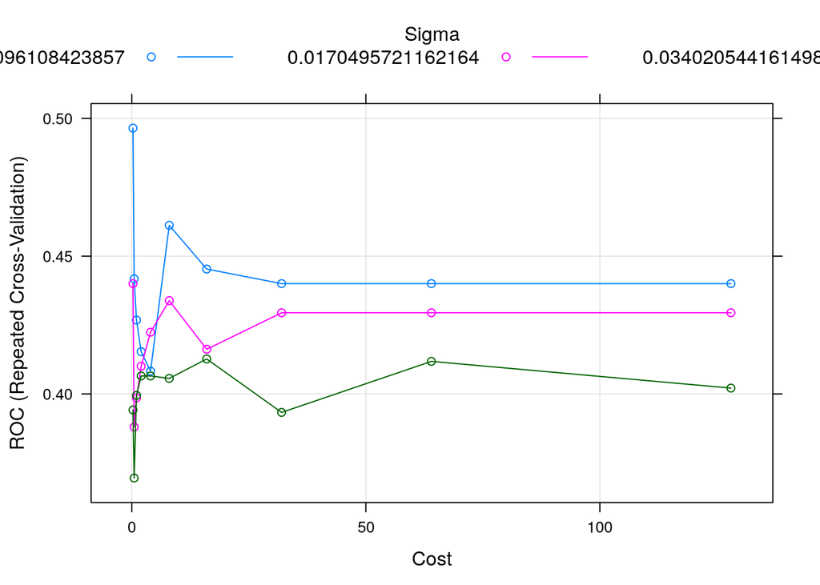

- Both linear and radial have `ROC` values that are way less compared to the previous models (esp Random FOrest).
- There isn’t a variable importance measure for the svm algorithms (but a penalizedSVM algorithm has a regualarization method that maybe able to).

# 6 K-Nearest Neighbour

- Using a [KNN algorithm](https://en.wikipedia.org/wiki/KNN), we used a similar approach to hyperparameter selection using 5x10CV.

## 6.1 KNN with 5x 10-CV

- Here, we are going to tune the number of nearest neighbor (`k`)

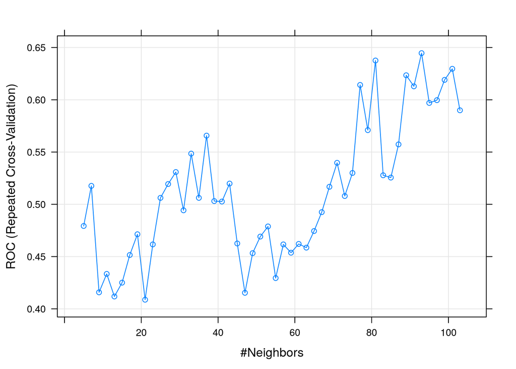

- Similar to SVM, the algorithm itself doesn’t perform all too well. The ROC values are lower compared to the random forest model.
- There isn’t a variable importance measure for knn algorithm.

# 7 Conclusion

So far we have used glm, decision tree, random forest, support vector machines, and k nearest neighbor algorithm to determine which algorithm produces the best predicting (based on area under the ROC curve) model. The objective was to train a model that has the optimal hyperparameter values and the optimal features/variables. The optimal model was chosen through iteratively training and testing the model on the sample using a 5x-10CV resampling method. Here is an overall summary of the algorithms based on the ROC values:

- The glm model with platelet stabilization time had the highest ROC value. However, the model including those variables excluded all biomarkers except for a few biomarkers.
- When excluding platelet stabilization time, the random forest model and knn model had the highest ROC.
- Important variables identified from the random forest model was hb, age, and hct.

Based on the analysis, platelet stabilization seems to be the key to identifying mortality. Multiclass classification could be useful but since we only have 73 patients, even binary classification runs the risk of small sample size with larger number of potential predictors (here we have ~ 40).

For analysis performed on biomarkers categorized as either binary or 3 categories (normal, high and low), clici here.

For the next analyses (i.e. Stacked Analysis) click here. From here on out the focus isn’t necessarily to find the most predictive marker.